# Overlapping: simulation 25/01

Massimiliano Pastore

```
2025-11-13
```

# Simulation

Il disegno sperimentale prevede 8 casi di confronto tra due campioni di dati, il primo dei quali ha sempre distribuzione $N(0,1)$, ed il secondo con le seguenti condizioni:

- $\mu$ = 0, 2
- $\sigma$ = 1, 5
- $\alpha$ = 0, 10

Come numerosità campionaria prendiamo $n$ = 10, 50, 100, 300, 500, 1000.

Di seguito rappresentiamo le condizioni sperimentali; le curve nere sono la prima popolazione, sempre $SN(0,1,0) = N(0,1)$, mentre le curve rosse la seconda popolazione $SN(\xi,\omega,\alpha)$, la cui media è rappresentata dalle linee verticali tratteggiate.

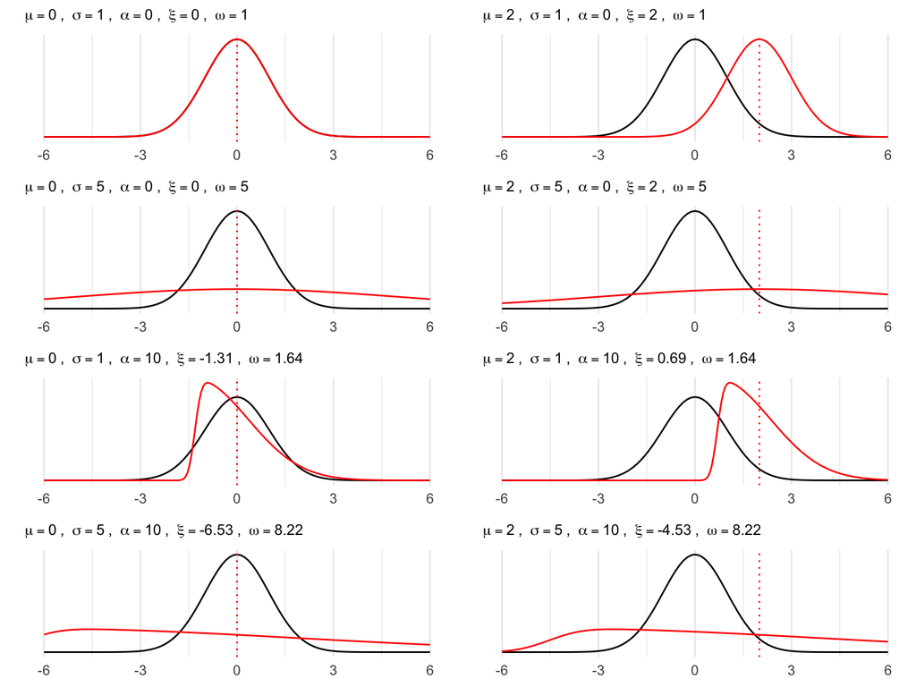

Figura 1: Rappresentazione della simulazione. Per ogni pannello le curve nere sono relative alla prima popolazione $SN(0,1,0) = N(0,1)$, le curve rosse sono relative alla seconda popolazione $SN(\xi,\omega,\alpha)$.

### Valori veri di $\eta$, OV, Cohen’s $d$ e Cles

Prendiamo in esame i seguenti indici: $\eta$ (overlapping non parametrico), OV (overlapping parametrico), Cohen’s $d$ e Cles. Per il calcolo dei valori veri, usiamo le seguenti funzioni:

```r
min_dskew_normal <- function( x = seq( -5, 5, by = .01 ), xi = 0, omega = 1, alpha = 0,
                              return.all = FALSE ) {

  require( sn )
  y1 <- dsn( x, xi = 0, omega = 1, alpha = 0 )
  y2 <- dsn( x, alpha = alpha, xi = xi, omega = omega )
  dy <- ifelse( y1 < y2, y1, y2 )
  gData <- data.frame( x, y1, y2, dy )

  if (return.all) {
    return( list( gData = gData ) )
  } else {
    return( dy )
  }
}

true_cohen <- function( mu1, mu2, sigma1, sigma2 ) {
  pool.s <- sqrt( (sigma1^2 + sigma2^2) / 2 )
  (mu1-mu2) / pool.s
}

true_CLES <- function( true_d ) {
  pnorm( abs(true_d) / sqrt(2) )
}
```

La funzione `min_dkew_normal()` ci permette di calcolare l’integrale esatto di sovrapposizione tra una normale ed una SN; la funzione `true_cohen()` calcola il vero Cohen’s $d$ a partire da medie e deviazioni standard delle popolazioni, `true_CLES()` calcola, a partire da $d$, il valore di Cles, con la formula $\Phi(|d|/\sqrt{2})$, in cui $\Phi$ è la cumulata della normale standard. Il vero valore di OV, dovrebbe essere sempre l’area di sovrapposizione e quindi deve essere uguale a quello ottenuto con integrale.

Ad esempio:

- Con $\mu = 0$, $\sigma = 1$ e $\alpha = 0$; le due distribuzioni sono uguali:

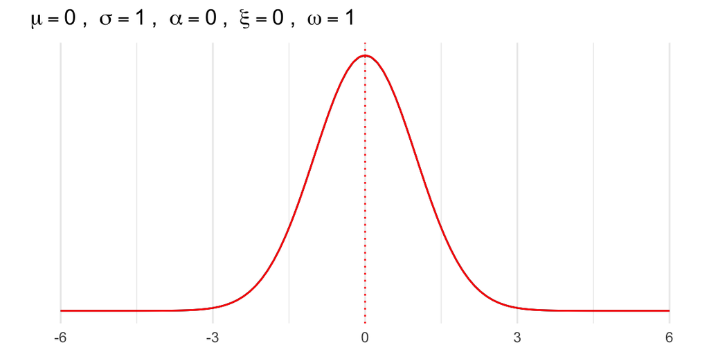

```r
# mu = 0, sigma = 1, alpha = 0
integrate( min_dskew_normal, -6, 6 )
```

```
1 with absolute error < 1.2e-07
```

```r
(d <- true_cohen( 0, 0, 1, 1 ))
```

```
[1] 0
```

```r
true_CLES( d )
```

```
[1] 0.5
```

**Esempio empirico**

Proviamo con dei dati simulati ($n = 10^{4}$)

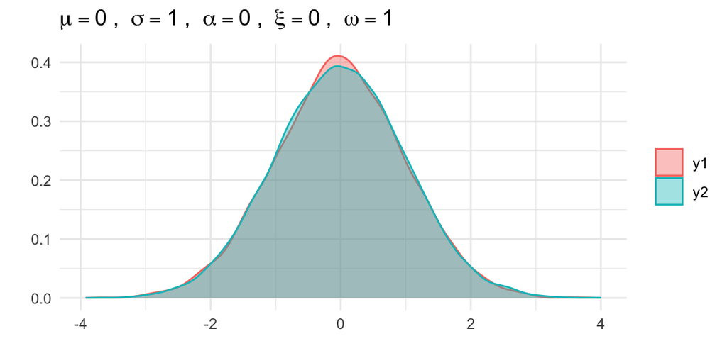

```r
library( overlapping )
overlap( list( y1, y2) )
```

```
$OV
[1] 0.9861702
```

```r
library( effectsize )
p_overlap( y1, y2, ci = LEVEL )
```

```
Overlap |       90% CI
----------------------
1.00    | [0.99, 1.00]
```

```r
cohens_d( y1, y2, ci = LEVEL )
```

```
Cohen's d |        90% CI
-------------------------
-5.92e-03 | [-0.03, 0.02]

- Estimated using pooled SD.
```

```r
CLES_IC( y1, y2 )$CLES
```

```
[1] 0.5009654
```

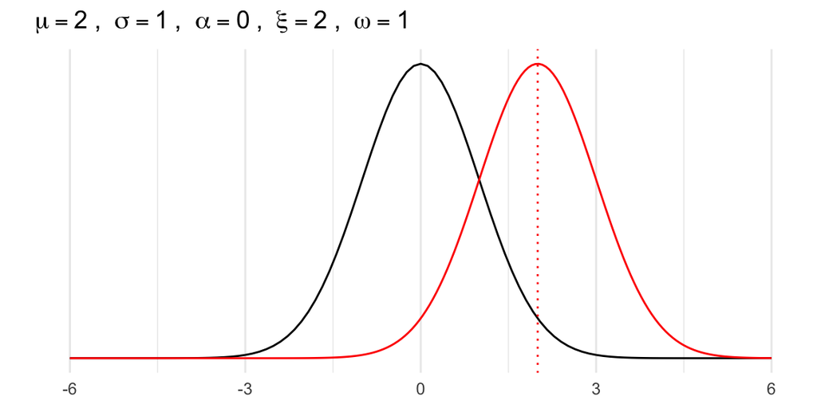

```r
# mu = 2, sigma = 1, alpha = 0
integrate( min_dskew_normal, -6, 6, xi = 2, omega = 1 )
```

```
0.3173105 with absolute error < 0.00011
```

```r
(d <- true_cohen( 0, 2, 1, 1 ))
```

```
[1] -2
```

```r
true_CLES( d )
```

```
[1] 0.9213504
```

**Esempio empirico**

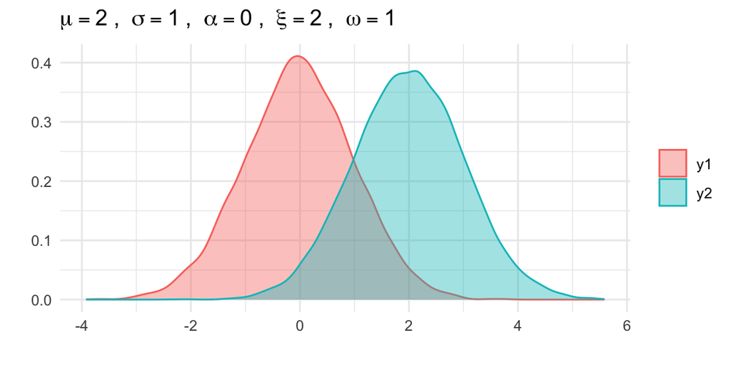

```r
overlap( list( y1, y2) )
```

```
$OV
[1] 0.3231647
```

```r
p_overlap( y1, y2, ci = LEVEL )
```

```
Overlap |       90% CI
----------------------
0.32    | [0.31, 0.33]
```

```r
cohens_d( y1, y2, ci = LEVEL )
```

```
Cohen's d |         90% CI
--------------------------
-2.00     | [-2.02, -1.97]

- Estimated using pooled SD.
```

```r
CLES_IC( y1, y2 )$CLES
```

```
[1] 0.9212706
```

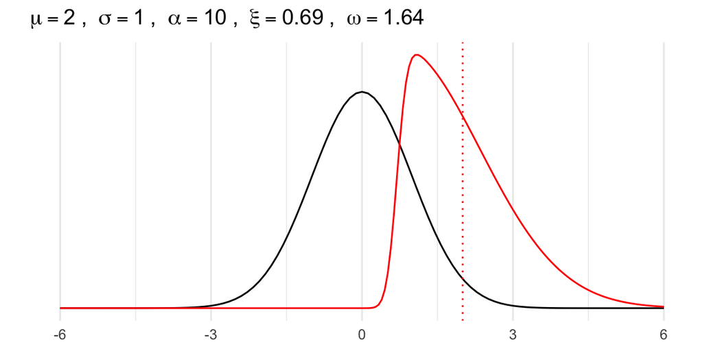

```r
# mu = 2, sigma = 1, alpha = 10
pars <- sninvpar( 2, 1, alpha = 10 )
integrate( min_dskew_normal, -6, 6,
           xi = pars$xi, omega = pars$omega, alpha = pars$alpha )
```

```
0.2736752 with absolute error < 8.1e-05
```

```r
(d <- true_cohen( 0, 2, 1, 1 ))
```

```
[1] -2
```

```r
true_CLES( d )
```

```
[1] 0.9213504
```

Notiamo che in questo caso, nonostante la forte asimmetria, Cohen’s $d$ e Cles rimangono invariati, proprio perché nelle formule di calcolo si tiene conto solo di media e deviazione standard.

**Esempio empirico**

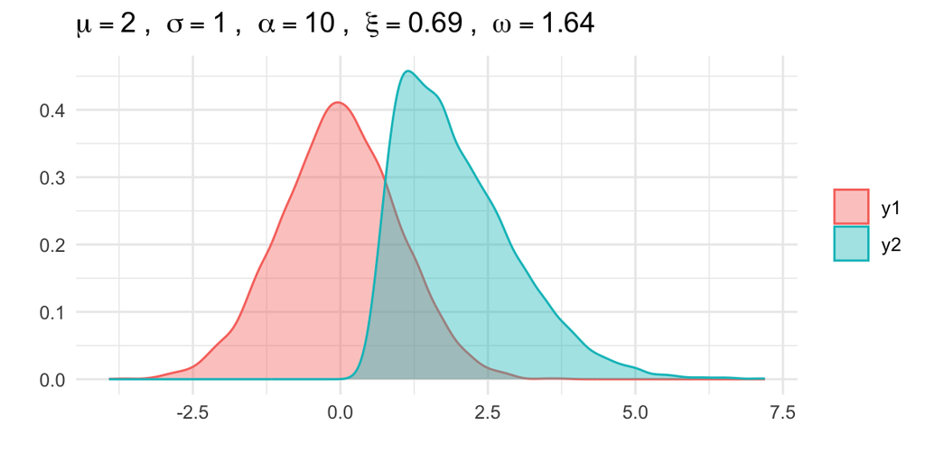

```r
overlap( list( y1, y2) )
```

```
$OV
[1] 0.28003
```

```r
p_overlap( y1, y2, ci = LEVEL )
```

```
Overlap |       90% CI
----------------------
0.31    | [0.31, 0.32]
```

```r
cohens_d( y1, y2, ci = LEVEL )
```

```
Cohen's d |         90% CI
--------------------------
-2.01     | [-2.04, -1.98]

- Estimated using pooled SD.
```

```r
CLES_IC( y1, y2 )$CLES
```

```
[1] 0.9348342
```

Si nota che anche l’indice OV, stima bene il grado di sovrapposizione, nonostante la marcata asimmetria della seconda distribuzione.

### Algoritmo simulazione

L’algoritmo per la simulazione è incluso nella seguente funzione, che prende in input `DESIGN`, lista di liste con i valori di $n$, $\xi$, $\alpha$ e $\omega$ per ciascuna combinazione del disegno sperimentale, e `B`, numero di repliche per condizione:

```
core_sim <- function( DESIGN, B = 10 ) {

  require(overlapping)
  require(sn)
  require(effectsize)
  # set simulation parameters
  n <- DESIGN$n
  delta <- DESIGN$xi
  alpha <- DESIGN$alpha
  omega <- DESIGN$omega

  # calcolo mu e sigma
  MUSI <- snpar(xi = delta, omega = omega, alpha = alpha)

  cat( paste0( "n = ",n,"; mu = ",round(MUSI$mu,1),
               "; sigma = ",round(MUSI$sigma,2),"; alpha = ",
               round(alpha,2) ),"\n")

  # true population overlap
  true_overlap <- integrate( min_dskew_normal, -Inf, Inf, xi = delta, alpha = alpha,
                             omega = omega )$value

  # true population Cohen's d
  true_d <- true_cohen( mu1 = 0, mu2 = MUSI$mu, sigma1 = 1,
                        sigma2 = MUSI$sigma )

  # data simulation
  t( sapply(1:B, function(b){

    y1 <- rsn(n,xi=0, omega=1, alpha=0)
    y2 <- rsn(n,xi=delta, omega=omega,alpha=alpha)

    mx1 <- mean(y1); sx1 <- sd(y1)
    mx2 <- mean(y2); sx2 <- sd(y2)

    ETA1 <- overlap(list(y1,y2))$OV
    ETA2 <- overlap(list(y1,y2), type = "2" )$OV
    COHEN <- cohens_d(y1,y2, ci = .9)
    CLES <- d_to_overlap(COHEN$Cohens_d)
    COHEN_CI_low <- COHEN$CI_low
    COHEN_CI_high <- COHEN$CI_high
    ETA_boot <- boot.overlap( list(y1,y2), B = 200 )
    ETA_CI <- quantile( ETA_boot$OVboot_dist, probs = c(.05,.95))

    output <- c( mx1, sx1, mx2, sx2, ETA1, ETA2, n,
                 delta, alpha, omega,
                 true_overlap, true_d, COHEN$Cohens_d, CLES,
                 COHEN_CI_low, COHEN_CI_high, ETA_CI[1], ETA_CI[2])
    names(output) <- c( "mx1", "sx1", "mx2", "sx2", "eta1", "eta2", "n",
                        "xi","alpha","omega",
                        "true_overlap", "true_d","Cohens_d","cles",
                        "Cohen_low","Cohen_high",
                        "eta_low", "eta_high")
    return(output)
  }) )
}
```

# Results

Nella Tabella 1 è riportato il numero di repliche per ciascuna combinazione di $\mu$, $\sigma$ e $\alpha$; tale numero va diviso per 6, ovvero il numero di combinazioni di $n$, per avere il numero effettivo di repliche per cella del disegno, ovvero 2000.

Tabella 1: Numero di repliche effettive per ciascuna combinazione di $\mu$, $\sigma$ e $\alpha$.

| mu | sigma | alpha | Freq |
| --- | --- | --- | --- |
| 0 | 1 | 0 | 12000 |
| 2 | 1 | 0 | 12000 |
| 0 | 5 | 0 | 12000 |
| 2 | 5 | 0 | 12000 |
| 0 | 1 | 10 | 12000 |
| 2 | 1 | 10 | 12000 |
| 0 | 5 | 10 | 12000 |
| 2 | 5 | 10 | 12000 |

### Valori veri e stimati

Prima di tutto analizziamo i valori veri dei tre indici presi in esame. Poiché manca `true_cles`, lo calcoliamo, a partire dai valori di `true_d`:

```r
ALL$true_cles <- true_CLES( ALL$true_d )
```

Ricordiamo che i valori veri di OV corrispondono ai valori veri di $\eta$ ottenuti via integrazione.

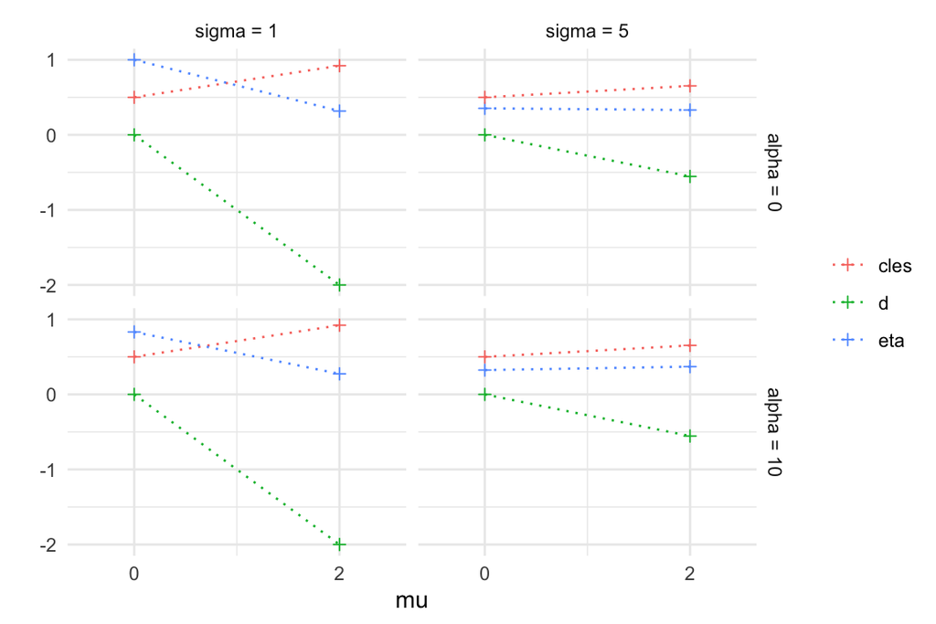

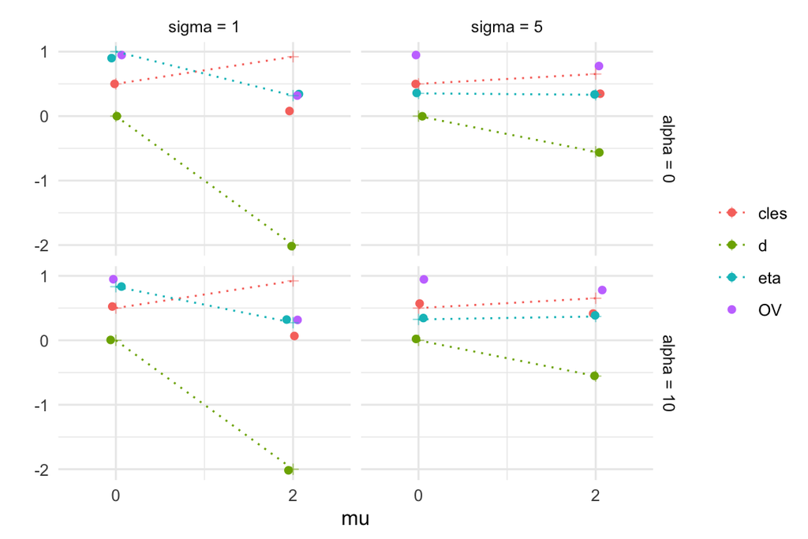

Figura 3: Medie dei valori stimati dei quattro indici nelle condizioni sperimentali.

### Descrittive degli indici

Vediamo in dettaglio, le distribuzioni dei valori degli indici nelle 8 condizioni sperimentali.

Tabella 2: Medie e range degli indici in funzione delle combinazioni di $\mu$, $\sigma$ e $\alpha$.

| mu | sigma | alpha | d | range_d | eta | range_eta | cles | range_cles | ov | range_ov |
| --- | --- | --- | --- | --- | --- | --- | --- | --- | --- | --- |
| 0 | 1 | 0 | 0.00 | -1.867; 1.729 | 0.90 | 0.322; 0.986 | 0.50 | 0.08; 0.95 | 0.95 | 0.351; 1 |
| 2 | 1 | 0 | -2.02 | -5.269; -0.632 | 0.34 | 0.002; 0.84 | 0.08 | 0; 0.34 | 0.32 | 0.008; 0.752 |
| 0 | 5 | 0 | 0.00 | -2.257; 1.935 | 0.36 | 0.09; 0.869 | 0.50 | 0.01; 0.92 | 0.95 | 0.259; 1 |
| 2 | 5 | 0 | -0.56 | -3.694; 1.364 | 0.34 | 0.047; 0.85 | 0.35 | 0; 0.79 | 0.78 | 0.065; 1 |
| 0 | 1 | 10 | 0.01 | -1.459; 2.293 | 0.83 | 0.204; 0.981 | 0.52 | 0.12; 0.94 | 0.95 | 0.252; 1 |
| 2 | 1 | 10 | -2.02 | -5.025; -0.235 | 0.32 | 0.006; 0.848 | 0.07 | 0; 0.49 | 0.32 | 0.012; 0.906 |
| 0 | 5 | 10 | 0.02 | -1.479; 2.903 | 0.35 | 0.034; 0.894 | 0.57 | 0.11; 0.97 | 0.95 | 0.147; 1 |
| 2 | 5 | 10 | -0.55 | -2.43; 1.351 | 0.39 | 0.077; 0.894 | 0.42 | 0.02; 0.88 | 0.78 | 0.224; 1 |

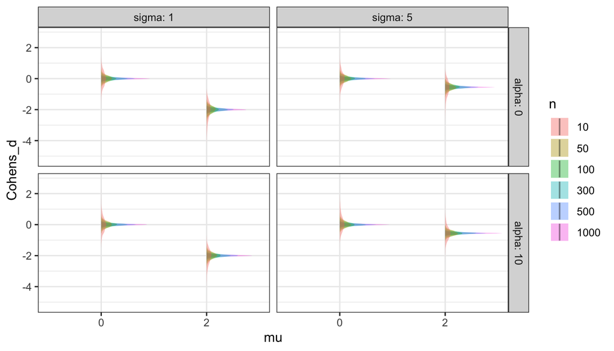

Figura 4: Distribuzioni di Cohen’s $d$ in funzione delle condizioni sperimentali $\mu$ (in ascissa), $\sigma$ (pannelli per colonna), $\alpha$ (pannelli per riga) e $n$ (colori).

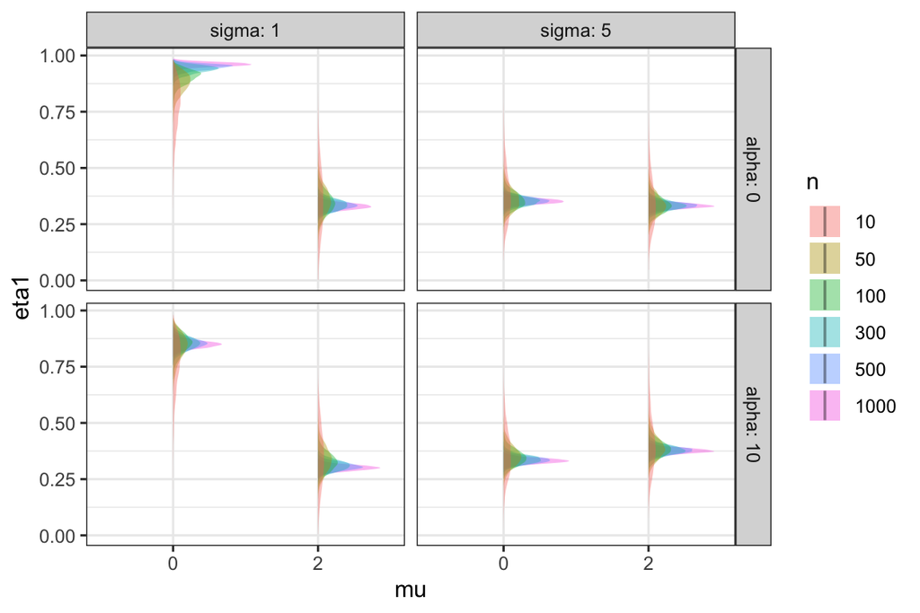

Figura 5: Distribuzioni di $\eta_1$ in funzione delle condizioni sperimentali $\mu$ (in ascissa), $\sigma$ (pannelli per colonna), $\alpha$ (pannelli per riga) e $n$ (colori).

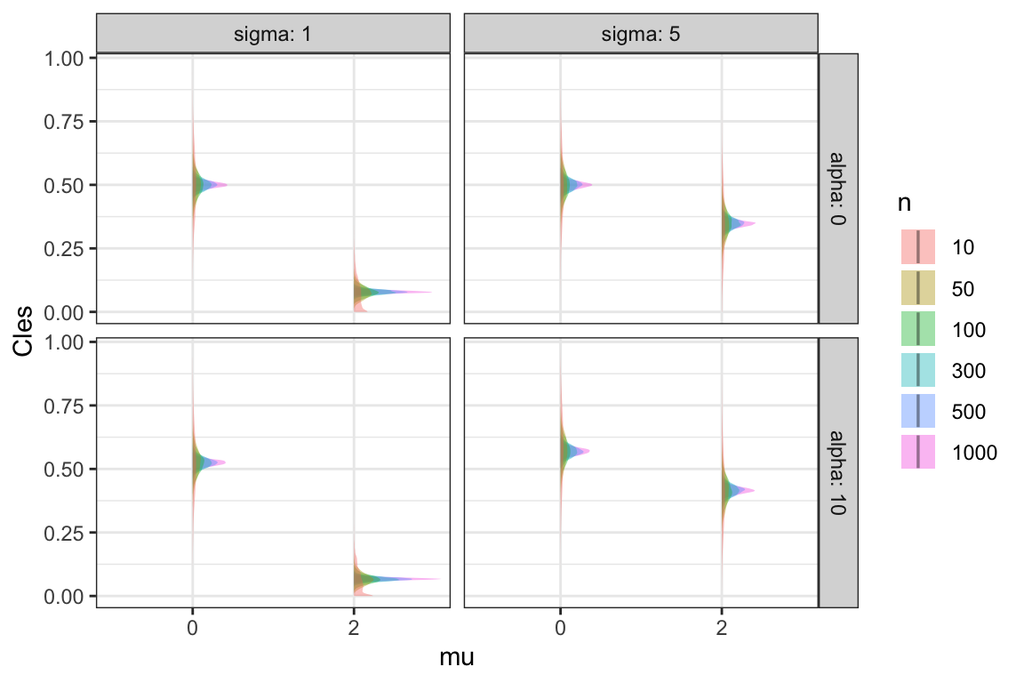

Figura 6: Distribuzioni di Cles in funzione delle condizioni sperimentali $\mu$ (in ascissa), $\sigma$ (pannelli per colonna), $\alpha$ (pannelli per riga) e $n$ (colori).

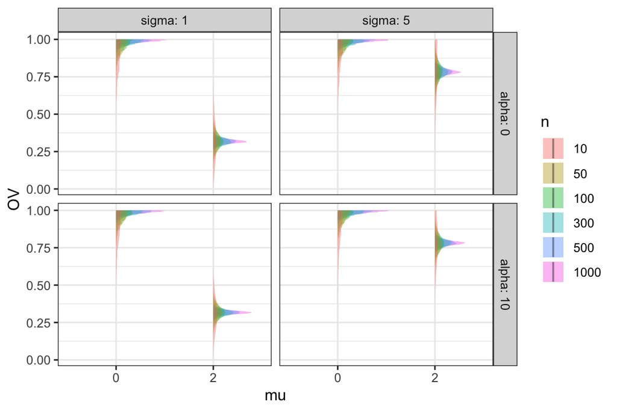

Figura 7: Distribuzioni di OV in funzione delle condizioni sperimentali $\mu$ (in ascissa), $\sigma$ (pannelli per colonna), $\alpha$ (pannelli per riga) e $n$ (colori).

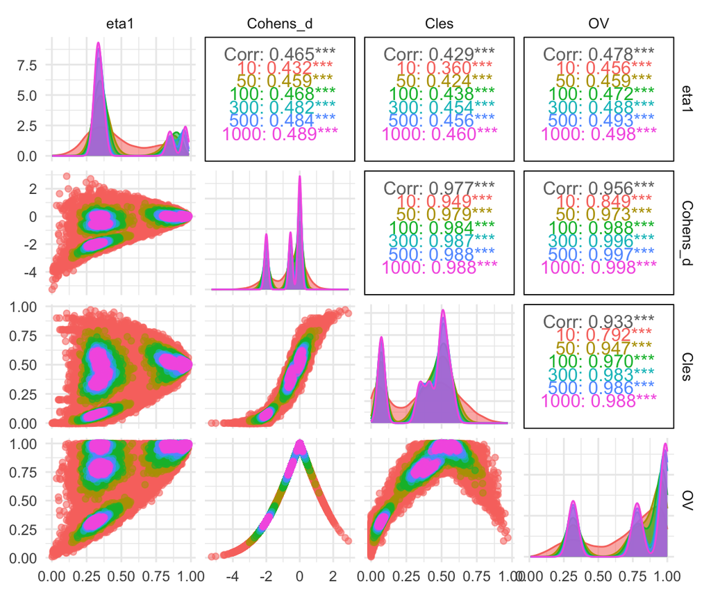

Figura 8: Correlazioni tra gli indici.

### Modelli sugli indici

Per quantificare gli effetti delle condizioni sperimentali sulle stime degli indici, utilizziamo dei modelli definiti con l’equazione
$$y \sim n \times \mu \times \sigma \times \alpha$$
in cui $y$ è l’indice preso in esame e $n \times \mu \times \sigma \times \alpha$ indica che si considerano tutti gli effetti fino all’interazione quadrupla (!!!).

Per Cohen’s $d$, che è una misura senza un range definito, possiamo utilizzare semplicemente un modello lineare, dal quale ricaviamo tutti gli $\eta^2$. E speriamo di non far casino tra $\eta^2$ (effect size derivato dalla varianza spiegata) e $\eta$ (indice di overlapping).

Relativamente a $\eta$ e Cles, che invece sono vincolati nell’intervallo $[0,1]$, usiamo dei modelli di regressione beta (Cribari-Neto & Zeileis, 2010) e, successivamente, calcoliamo delle proporzioni di devianza spiegata, che dovrebbero essere simili agli $\eta^2$ dei modelli lineari.

In Tabella 3 sono riportati tutti gli effect size relativi alle combinazioni dei fattori sperimentali.

Tabella 3: Proporzione di varianza/devianza spiegata per ciascuna combinazione di $n$ $\mu$, $\sigma$ e $\alpha$.

| Parameter | cohen | eta | cles | ov |
| --- | --- | --- | --- | --- |
| n | 0.00 | 0.05 | 0.00 | 0.01 |
| mu | 0.56 | 0.39 | 0.39 | 0.38 |
| sigma | 0.18 | 0.38 | 0.00 | 0.00 |
| alpha | 0.00 | 0.00 | 0.00 | 0.00 |
| n:mu | 0.00 | 0.04 | 0.00 | 0.01 |
| n:sigma | 0.00 | 0.04 | 0.00 | 0.00 |
| mu:sigma | 0.18 | 0.24 | 0.18 | 0.07 |
| n:alpha | 0.00 | 0.02 | 0.00 | 0.00 |
| mu:alpha | 0.00 | 0.00 | 0.01 | 0.00 |
| sigma:alpha | 0.00 | 0.00 | 0.00 | 0.00 |
| n:mu:sigma | 0.00 | 0.03 | 0.00 | 0.00 |
| n:mu:alpha | 0.00 | 0.01 | 0.00 | 0.00 |
| n:sigma:alpha | 0.00 | 0.01 | 0.00 | 0.00 |
| mu:sigma:alpha | 0.00 | 0.00 | 0.00 | 0.00 |
| n:mu:sigma:alpha | 0.00 | 0.01 | 0.00 | 0.00 |

### Indici di performance

Per confrontare le performance calcoliamo le seguenti statistiche:

- The **Absolute mean bias** (AMB): ottenuto come media dei bias assoluti: $1/B\sum_b (|\hat{\theta}_{bj}-\theta_j|)$ in cui $\theta_j$ è il valore vero nella condizione $j$ e $\hat{\theta}_{bj}$ quello stimato nella replica $b$ della condizione $j$. Questo indice dipende dalla scala e pertanto non lo possiamo usare per fare confronti.
- The **Relative mean bias** (RMB): ottenuto come media dei bias relativi: $1/B\sum_b (\hat{\theta}_{bj}-\theta_j)/\theta_j$. Relative bias included between -0.1 and 0.1 are considered acceptable. Nota bene: quando il vero valore $\theta_j = 0$, per evitare risultati `NaN`, viene sostituito da un numero molto piccolo $\epsilon = 10^{-6}$.
- The **Mean Square Error** (MSE), defined as $\sigma_j^2 + [1/B \sum_b (\hat{\theta}_{bj}-\theta_j)]^2$, with $\sigma_j^2$ being the variance of the estimates across replications. The lower the MSE, the closer is forecast to actual.
- The **Root Mean Square Error** (RMSE), defined as $\sqrt{MSE}$. The lower the RMSE, the closer is forecast to actual.
- The **Normalized Root Mean Square Error** (NRMSE), defined as $RMSE/ (max(obs)-min(obs))$; ovvero divide il valore di RMSE per il range dei valori stimati.

Considerato che i tre indici non sono comparabili in senso assoluto, utilizziamo solo RMB (Figura 9) e NRMSE (Figura 10). Nel caso di quest’ultimo indice, aggiungiamo anche un secondo grafico (Figura 11) in cui escludiamo Cles, che ha una performance molto perggiore degli altri.

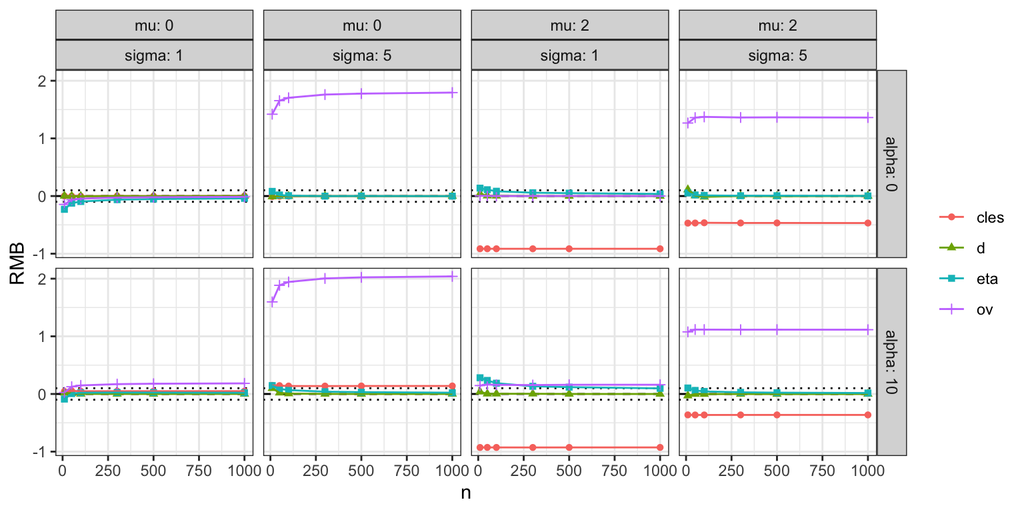

Figura 9: Relative mean bias in funzione delle condizioni sperimentali.

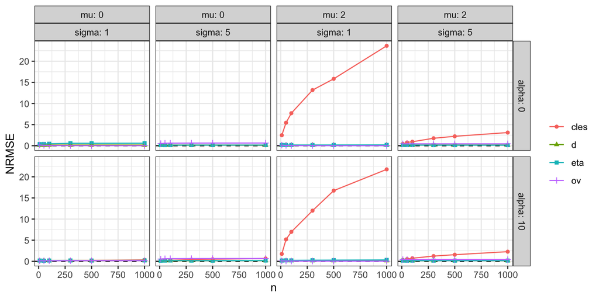

Figura 10: Normalized relative mean square error in funzione delle condizioni sperimentali.

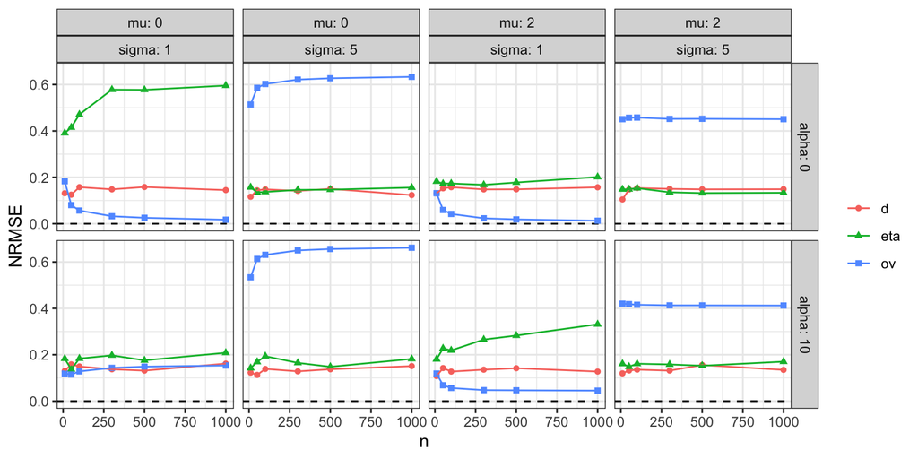

Figura 11: Normalized relative mean square error in funzione delle condizioni sperimentali. In questo caso Cles è escluso perchè ha una performance nettamente peggiore degli altri.

### Coverage

```r
# per provare
ALL$OV_low <- d_to_overlap( ALL$Cohen_low )
ALL$OV_high <- d_to_overlap( ALL$Cohen_high )

ALL$coverage_d <- with( ALL,
    (Cohen_low < true_d) & (Cohen_high > true_d ) )
ALL$coverage_eta <- with( ALL,
    (eta1_low < true_overlap) & (eta1_high > true_overlap ) )
ALL$coverage_ov <- with( ALL,
    (OV_low < true_overlap) & (OV_high > true_overlap ) )
ALL$coverage_cles <- with( ALL,
    (Cles_low < true_cles) & (Cles_high > true_cles ) )
```

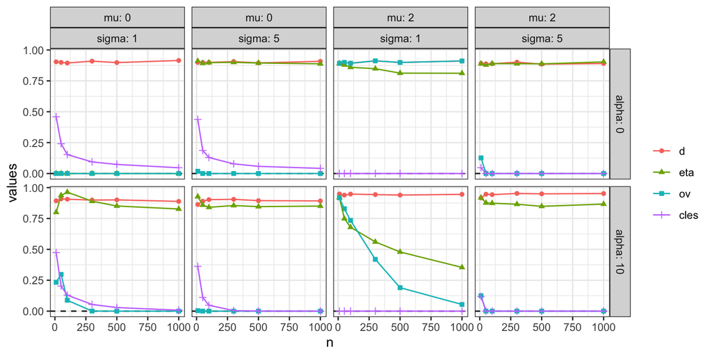

Figura 12: Coverage 90%.

Appare controintuitiva la performance di $\eta$ nella condizione $\mu = 2$, $\sigma = 1$, $\alpha = 10$, quindi vediamo, in Figura 13 la distribuzione dei valori stimati in questa condizione, in funzione di $n$. Se calcoliamo il valore vero via integrale, abbiamo:

```r
pars <- sninvpar( mu = 2, sigma = 1, alpha = 10 )

integrate( min_dskew_normal, -6, 6,
           xi = pars$xi, omega = pars$omega, alpha = pars$alpha )
```

```
0.2736752 with absolute error < 8.1e-05
```

Tale valore viene riportato in figura con linea orizzontale punteggiata.

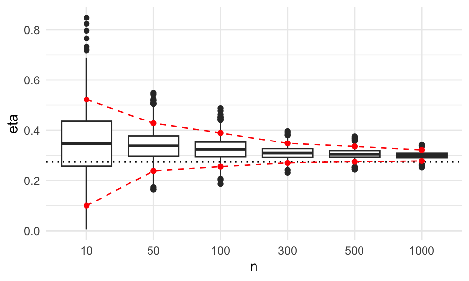

Figura 13: Distribuzioni, in funzione di $n$, delle stime di $\eta$ nello scenario: $\mu = 2$, $\sigma = 1$, $\alpha = 10$. Le linee rosse tratteggiate indicano i valori medi di confidenza al 90%.

Proviamo a controllare con una simulazione:

```r
set.seed( 1 )
n <- 1000
y1 <- rsn( n, xi=0, omega=1, alpha=0 )
y2 <- with( pars, rsn( n, xi=xi, omega=omega, alpha=alpha ) )

BOV <- boot.overlap( list( y1 = y1, y2 = y2 ) )
BOV$OVboot_stats
```

```
      estOV          bias         se
1 0.3115051 -0.0003062217 0.01317652
```

```r
quantile( BOV$OVboot_dist, probs = PROBS )
```

```
       5%       95%
0.2895287 0.3331825
```

L’intervallo non contiene il valore vero 0.2736752.

Nota: se però modifichiamo il parametro `bw`

```r
BOV <- boot.overlap( list( y1 = y1, y2 = y2 ), bw = .001 )
BOV$OVboot_stats
```

```
      estOV        bias         se
1 0.2657817 -0.03287813 0.01157847
```

```r
(QQ <- quantile( BOV$OVboot_dist, probs = PROBS ))
```

```
       5%       95%
0.2132067 0.2519116
```

La stima puntuale è più vicina al valore vero. Abbiamo però trovato un *bug* nella funzione `boot.overlap()`; si vede che l’intervallo di confidenza, calcolato via bootstrap non contiene il valore stimato!!!

## References

Cribari-Neto, F., & Zeileis, A. (2010). Beta regression in R. *Journal of Statistical Software*, *34*(2), 1–24. https://doi.org/10.18637/jss.v034.i02

## Used R Packages

- `cowplot` Wilke C (2024). _cowplot: Streamlined Plot Theme and Plot Annotations for ‘ggplot2’_. R package version 1.1.3, https://CRAN.R-project.org/package=cowplot.
- `effectsize` Ben-Shachar MS, Lüdecke D, Makowski D (2020). “effectsize: Estimation of Effect Size Indices and Standardized Parameters.” _Journal of Open Source Software_, *5*(56), 2815. doi:10.21105/joss.02815 https://doi.org/10.21105/joss.02815, https://doi.org/10.21105/joss.02815.
- `GGally` Schloerke B, Cook D, Larmarange J, Briatte F, Marbach M, Thoen E, Elberg A, Crowley J (2024). _GGally: Extension to ‘ggplot2’_. R package version 2.2.1, https://CRAN.R-project.org/package=GGally.
- `ggdist` Kay M (2024). “ggdist: Visualizations of Distributions and Uncertainty in the Grammar of Graphics.” _IEEE Transactions on Visualization and Computer Graphics_, *30*(1), 414-424. doi:10.1109/TVCG.2023.3327195 https://doi.org/10.1109/TVCG.2023.3327195. Kay M (2024). _ggdist: Visualizations of Distributions and Uncertainty_. doi:10.5281/zenodo.3879620 https://doi.org/10.5281/zenodo.3879620, R package version 3.3.2, https://mjskay.github.io/ggdist/.
- `ggplot2` Wickham H (2016). _ggplot2: Elegant Graphics for Data Analysis_. Springer-Verlag New York. ISBN 978-3-319-24277-4, https://ggplot2.tidyverse.org.
- `kableExtra` Zhu H (2024). _kableExtra: Construct Complex Table with ‘kable’ and Pipe Syntax_. R package version 1.4.0, https://CRAN.R-project.org/package=kableExtra.
- `knitr` Xie Y (2025). _knitr: A General-Purpose Package for Dynamic Report Generation in R_. R package version 1.50, https://yihui.org/knitr/. Xie Y (2015). _Dynamic Documents with R and knitr_, 2nd edition. Chapman and Hall/CRC, Boca Raton, Florida. ISBN 978-1498716963, https://yihui.org/knitr/. Xie Y (2014). “knitr: A Comprehensive Tool for Reproducible Research in R.” In Stodden V, Leisch F, Peng RD (eds.), _Implementing Reproducible Computational Research_. Chapman and Hall/CRC. ISBN 978-1466561595.
- `overlapping` Pastore M, Loro PAD, Mingione M, Calcagni’ A (2024). _overlapping: Estimation of Overlapping in Empirical Distributions_. R package version 2.2.
- `R` R Core Team (2024). _R: A Language and Environment for Statistical Computing_. R Foundation for Statistical Computing, Vienna, Austria. https://www.R-project.org/.
- `report` Makowski D, Lüdecke D, Patil I, Thériault R, Ben-Shachar M, Wiernik B (2023). “Automated Results Reporting as a Practical Tool to Improve Reproducibility and Methodological Best Practices Adoption.” _CRAN_. https://easystats.github.io/report/.
- `sn` Azzalini AA (2023). _The R package : The skew-normal and related distributions such as the skew-$t$ and the SUN (version 2.1.1)._. Home page: http://azzalini.stat.unipd.it/SN/, https://cran.r-project.org/package=sn.
- `testthat` Wickham H (2011). “testthat: Get Started with Testing.” _The R Journal_, *3*, 5-10. https://journal.r-project.org/archive/2011-1/RJournal_2011-1_Wickham.pdf.